# 20 Years Of Games

## Introduction

In this document we look to analyse the data - 20 years of Games. A summary of the fields available is as shown below. As part of this report, we are going to describe the dataset, split the data into a test and training set and predict the likelihood that a game was made an editor’s choice. In this particular example, we’ll make use of the following R packages readr, ggplot2, dplyr, and caret

## Summaries

The data object is complex. It contains of the following columns - X1, score_phrase, title, platform, score, genre, editors_choice, release_year, release_month, release_day, release_date. The columns release_year, release_month, release_day were combinded to form release date. There are over 18624 titles for 59 different platforms and 113 genre of games for the past 20years. An overall summary of the dataset includes as follows

```r
summary(df_p)
```

```
       X1          score_phrase     title                    platform        score             genre      editors_choice
 Min.   :    0   Great   :4772   Length:18624       PC           :3370   Min.   : 0.50   Action   :3797   N:15107
 1st Qu.: 4657   Good    :4741   Class :character   PlayStation 2:1686   1st Qu.: 6.00   Sports   :1916   Y: 3517
 Median : 9312   Okay    :2945   Mode  :character   Xbox 360     :1630   Median : 7.30   Shooter  :1610
 Mean   : 9312   Mediocre:1959                      Wii          :1366   Mean   : 6.95   Racing   :1228
 3rd Qu.:13968   Amazing :1804                      PlayStation 3:1356   3rd Qu.: 8.20   Adventure:1174
 Max.   :18624   Bad     :1269                      Nintendo DS  :1045   Max.   :10.00   (Other)  :8863
                 (Other) :1134                      (Other)      :8171                   NA's     :  36
  release_date
 Min.   :1996-06-18
 1st Qu.:2003-09-09
 Median :2007-09-06
 Mean   :2007-01-25
 3rd Qu.:2010-04-08
 Max.   :2016-09-22
```

An overall trend of the number of games during the years can be shown as below. As is visible from the graph, the PC gaming industry once had taken off hasn’t looked back.

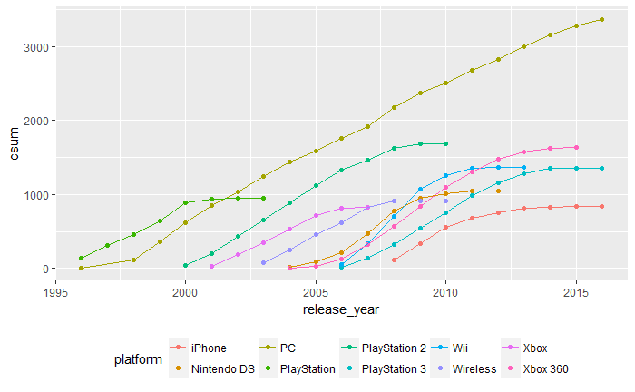

```r
df_plot = left_join(df_total,df,by ="platform") %>%
  group_by(platform,release_year) %>%
  summarise(count = n()) %>%
  group_by(platform) %>%
  arrange(release_year) %>%
  mutate(csum = cumsum(count))
ggplot(df_plot, aes(x=release_year, y = csum, colour = platform)) +
  geom_point() +
  geom_line() +
  theme(legend.position = "bottom")
```

## Predictive analysis

The aim of the predictive analysis is to calculate the likelihood that a game made was an editor’s choice. This is a classification type problem, and there are two popular methods to resolve this

- Logistic regression
- Support vector machine regression

### Logistic Regression

The dataframe will be split into training, testing. The data is split to 60:40 for training and testing.The reason for this choice of split is to better understand the underlying distribution and then test the results with the remaining 40% of the data.

```r
df_t <- df_p[complete.cases(df_p),]
df_t$editors_choice <- as.character(df_t$editors_choice)
train <-createDataPartition(y = 1:nrow(df_t),p = 0.6, list = FALSE)
training <- df_t[train,]
testing <- df_t[-train,]
```

The model is trained to test for the following formula `formula (editors_choice ~ platform + genre+ score_phrase + score)` using logistic regression.

```r
t1 <- confusionMatrix(predictions, testing$editors_choice)
print(t1)
```

```
Confusion Matrix and Statistics

          Reference
Prediction    N    Y
         N 5847  138
         Y  186 1261

               Accuracy : 0.9564
                 95% CI : (0.9515, 0.9609)
    No Information Rate : 0.8118
    P-Value [Acc > NIR] : < 2.2e-16

                  Kappa : 0.8592
 Mcnemar's Test P-Value : 0.009025

            Sensitivity : 0.9692
            Specificity : 0.9014
         Pos Pred Value : 0.9769
         Neg Pred Value : 0.8715
             Prevalence : 0.8118
         Detection Rate : 0.7867
   Detection Prevalence : 0.8053
      Balanced Accuracy : 0.9353

       'Positive' Class : N
```

### Support vector machine

```r
t2 <- confusionMatrix(predictions2, testing$editors_choice)
print(t2)
```

```
Confusion Matrix and Statistics

          Reference
Prediction    N    Y
         N 5823  121
         Y  210 1278

               Accuracy : 0.9555
                 95% CI : (0.9505, 0.96)
    No Information Rate : 0.8118
    P-Value [Acc > NIR] : < 2.2e-16

                  Kappa : 0.8577
 Mcnemar's Test P-Value : 1.319e-06

            Sensitivity : 0.9652
            Specificity : 0.9135
         Pos Pred Value : 0.9796
         Neg Pred Value : 0.8589
             Prevalence : 0.8118
         Detection Rate : 0.7835
   Detection Prevalence : 0.7998
      Balanced Accuracy : 0.9394

       'Positive' Class : N
```